# Reporte

EmilySoto

6/9/2021

## Assumptions

1. El df es de un solo producto

```
## [1] 0.25
```

2. Los clientes con “faltante” son ordenes que faltaron en despachos anteriores
3. Los clientes con “Devolución” representan salida de dinero ya que son devoluciones

| …1 | COD_VIAJE | CLIENTE | UBICACION | CANTIDAD | PILOTO | Q | CREDITO | UNIDAD | MES | ANIO |
| --- | --- | --- | --- | --- | --- | --- | --- | --- | --- | --- |
| 9 | 10000009 | EL GALLO NEGRO \|\|\|DEVOLUCION | 76002 | -1601 | Ismael Rodero Monteagudo | -400.25 | 30 | Camion Grande | 1 | 2017 |
| 47 | 10000047 | EL GALLO NEGRO \|\|\|DEVOLUCION | 76002 | -362 | Luis Jaime Urbano | -90.50 | 90 | Panel | 1 | 2017 |
| 65 | 10000065 | EL GALLO NEGRO \|\|\|DEVOLUCION | 76001 | -1126 | Angel Valdez Alegria | -281.50 | 60 | Camion Grande | 1 | 2017 |
| 110 | 10000110 | EL GALLO NEGRO \|\|\|DEVOLUCION | 76001 | -696 | Luis Jaime Urbano | -174.00 | 60 | Camion Pequeño | 1 | 2017 |
| 124 | 10000124 | EL GALLO NEGRO \|\|\|DEVOLUCION | 76002 | -1618 | Felipe Villatoro | -404.50 | 30 | Camion Grande | 1 | 2017 |
| 135 | 10000135 | EL GALLO NEGRO \|\|\|DEVOLUCION | 76002 | -1280 | Fernando Mariano Berrio | -320.00 | 60 | Camion Grande | 1 | 2017 |
| 162 | 10000162 | EL GALLO NEGRO \|\|\|DEVOLUCION | 76002 | -209 | Fernando Mariano Berrio | -52.25 | 60 | Panel | 1 | 2017 |
| 174 | 10000174 | EL GALLO NEGRO \|\|\|DEVOLUCION | 76002 | -1398 | Angel Valdez Alegria | -349.50 | 60 | Camion Grande | 1 | 2017 |

## Análisis preliminar

Haciendo una breve exploración del dataset, se encontró algunos highlights que se resumen en:

#### 1. Estado de entrega

Hay 3 estados de despacho: Faltante|Despacho a cliente |DEVOLUCION

| …1 | COD_VIAJE | CLIENTE | UBICACION | CANTIDAD | PILOTO | Q | CREDITO | UNIDAD | MES | ANIO |
| --- | --- | --- | --- | --- | --- | --- | --- | --- | --- | --- |
| 2 | 10000002 | TAQUERIA EL CHINITO \|\|\|Faltante | 76002 | 1433 | Hector Aragones Frutos | 358.25 | 90 | Camion Grande | 1 | 2017 |
| 5 | 10000005 | CHICHARRONERIA EL RICO COLESTEROL \|\|\|Faltante | 76001 | 1644 | Juan Francisco Portillo Gomez | 411.00 | 30 | Camion Grande | 1 | 2017 |
| 7 | 10000007 | CHICHARRONERIA EL RICO COLESTEROL \|\|\|Faltante | 76002 | 1947 | Ismael Rodero Monteagudo | 486.75 | 90 | Camion Grande | 1 | 2017 |
| 8 | 10000008 | TAQUERIA EL CHINITO \|\|\|Faltante | 76001 | 1716 | Juan Francisco Portillo Gomez | 429.00 | 60 | Camion Grande | 1 | 2017 |
| 9 | 10000009 | EL GALLO NEGRO \|\|\|DEVOLUCION | 76002 | -1601 | Ismael Rodero Monteagudo | -400.25 | 30 | Camion Grande | 1 | 2017 |
| 10 | 10000010 | CHICHARRONERIA EL RICO COLESTEROL \|\|\|Faltante | 76002 | 1343 | Fernando Mariano Berrio | 335.75 | 90 | Camion Grande | 1 | 2017 |
| 17 | 10000017 | SPORTA, S.A./Despacho a cliente \|\|\|Faltante | 76002 | 1186 | Ismael Rodero Monteagudo | 296.50 | 30 | Camion Grande | 1 | 2017 |
| 26 | 10000026 | CHICHARRONERIA EL RICO COLESTEROL \|\|\|Faltante | 76002 | 840 | Juan Francisco Portillo Gomez | 210.00 | 30 | Camion Pequeño | 1 | 2017 |
| 28 | 10000028 | SPORTA, S.A./Despacho a cliente \|\|\|Faltante | 76002 | 1330 | Angel Valdez Alegria | 332.50 | 30 | Camion Grande | 1 | 2017 |
| 33 | 10000033 | EL PINCHE OBELISCO \|\|\|Faltante | 76002 | 875 | Juan Francisco Portillo Gomez | 218.75 | 60 | Camion Pequeño | 1 | 2017 |

#### 2. Clientes

Hay un total de 13 clientes activos

```
## # A tibble: 18 x 2
##    CLIENTE                                            `n_distinct()`
##    <chr>                                                       <int>
##  1 ABARROTERIA EBENEZER/Despacho a cliente                         0
##  2 BAR LA OFICINA                                                  0
##  3 CHICHARRONERIA EL RICO COLESTEROL |||Faltante                   0
##  4 EL GALLO NEGRO / Despacho a cliente                             0
##  5 EL GALLO NEGRO |||DEVOLUCION                                    0
##  6 EL PINCHE OBELISCO / Despacho a cliente                         0
##  7 EL PINCHE OBELISCO |||Faltante                                  0
##  8 HOSPITAL LAS AMERICAS                                           0
##  9 HOSPITAL ROOSEVELT / Despacho a cliente                         0
## 10 POLLO PINULITO/Despacho a cliente                               0
## 11 POLLO PINULITO|||FALTANTE                                       0
## 12 SPORTA, S.A./Despacho a cliente |||Faltante                     0
## 13 TAQUERIA EL CHINITO                                             0
## 14 TAQUERIA EL CHINITO |||Faltante                                 0
## 15 TIENDA LA BENDICION / Despacho a cliente                        0
## 16 UBIQUO LABS                                                     0
## 17 UBIQUO LABS |||FALTANTE                                         0
## 18 UNIVERSIDAD FRANCISCO MARROQUIN/Despacho a cliente              0
```

#### 3. Opción de crédito

Actualmente la empresa otorga hasta tres meses de crédito

[interactive chart not shown]

```
## # A tibble: 3 x 2
##   CREDITO Entregas
##     <dbl>    <int>
## 1      30      771
## 2      60      748
## 3      90      661
```

[interactive chart not shown]

El 30% de las ventas se realizan con un crédito de 90 días, lo que ocasiona que algunos flujos se reciban hasta el próximo año

[interactive chart not shown]

#### 4. Pilotos

Hay 9 pilotos activos dentro de la empresa

```
## # A tibble: 9 x 2
##   PILOTO                        FlujoMensual
##   <chr>                                <dbl>
## 1 Angel Valdez Alegria                53666.
## 2 Felipe Villatoro                    56688.
## 3 Fernando Mariano Berrio             70447.
## 4 Hector Aragones Frutos              59006.
## 5 Hector Giron                        60173.
## 6 Ismael Rodero Monteagudo            63770.
## 7 Juan Francisco Portillo Gomez       53404.
## 8 Luis Jaime Urbano                   54968.
## 9 Pedro Alvarez Parejo                60586.
```

Cada uno coloca dentro de 50K-70K quetzales

[interactive chart not shown]

Y en promedio, cada uno hace 20 entregas mensuales

[interactive chart not shown]

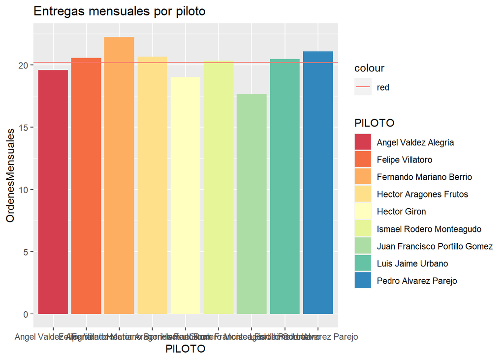

#### 5. Vehículos

La mayor parte de los despachos se hace con camión grande

[interactive chart not shown]

La mayoría de entregas faltantes terminan siendo despachadas con camiones grandes

[interactive chart not shown]

## PARETO

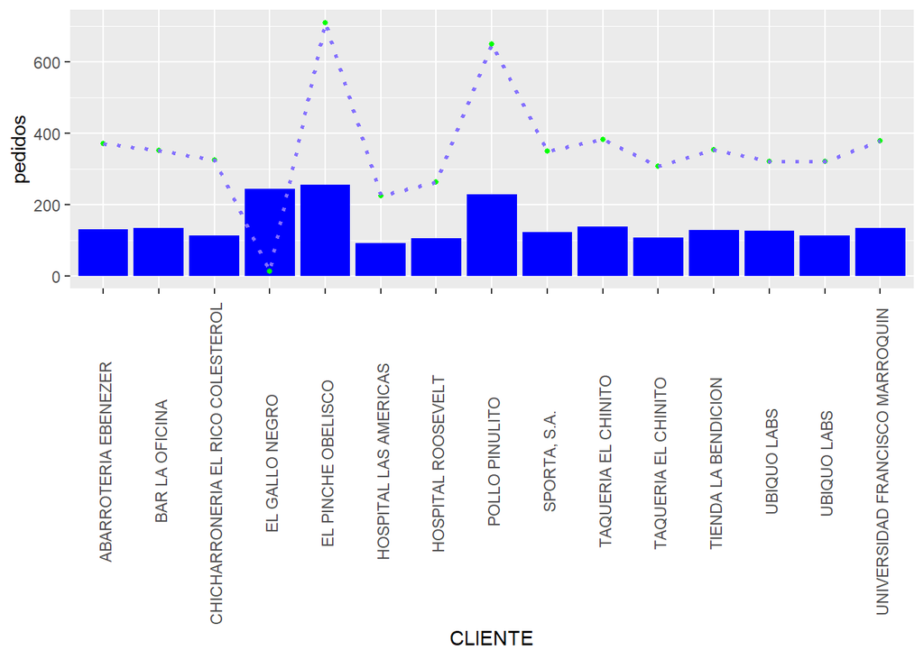